Skip to content

Akif MustafaBiostatistician.

# Multi-Crossover Designs in RCTs

What you gain by adding periods — and what it costs

Author

Akif Mustafa ✉

Published

September 11, 2026

Abstract

A practical guide to multi-crossover (higher-order) randomized controlled trial designs: how they are structured, how they are analysed, what they buy you, and when they break.

**Table of contents**

**In one paragraph.** A standard crossover gives each participant two treatments in two periods. A *multi-crossover* design gives them three or more. That extra structure lets you estimate within-subject variability per treatment, estimate carryover instead of assuming it away, compare more than two treatments, and survive dropout. The price is a longer trial, heavier logistics, and a stricter set of assumptions.

# 1 Why add periods?

In a parallel-group trial, each participant gets one treatment. Comparisons are made *between* people, so between-subject variability sits squarely in the denominator of your test statistic and inflates the sample size you need.

A crossover design removes that. Each participant receives more than one treatment in a randomised order, so the comparison is made *within* a person. When treatment effects are fast, reversible, and repeatedly measurable, this can be dramatically more efficient.

The familiar AB/BA crossover, however, is a fragile instrument. Carryover is aliased with the treatment-by-period interaction, so the two cannot be separated. A participant who drops out after the first period contributes nothing to the paired comparison. And only two treatments can be compared.

Adding periods fixes much of this. That is the subject of this article.

## 1.1 The standard crossover, briefly

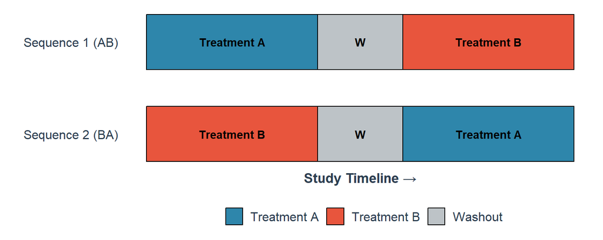

Figure 1: Standard two-period, two-sequence (AB/BA) crossover.

Four terms recur throughout:

- **Period** — an interval during which a participant receives and is assessed on one treatment.
- **Sequence** — the order of treatments assigned to a participant (AB, BA, ABAB, …).
- **Washout** — the gap between periods, long enough for the previous treatment’s effects to dissipate.
- **Within-subject comparison** — each participant’s response on one treatment compared against their own response on another.

Table 1: What breaks in a two-period crossover, and how extra periods help.

| Limitation | Two-Period Crossover | Multi-Crossover Resolution |
| --- | --- | --- |
| Carryover aliased with treatment × period interaction | Carryover can be tested, but only with very low power, and cannot be separated from treatment × period | Extra periods break the aliasing; carryover is estimable in balanced designs |
| Only two treatments comparable | One pairwise comparison | Williams and Latin Square designs handle ≥ 3 treatments |
| Dropout after Period 1 destroys the pairing | Participant contributes no within-subject information | Completing ≥ 2 of ≥ 3 periods still yields within-subject comparisons |
| No treatment-specific within-subject variance | Only a pooled within-subject variance is estimable | Replicated designs give a separate variance per treatment |

# 2 Design configurations

A **multi-crossover** (or higher-order) design is a crossover trial with three or more periods. It may involve two treatments repeated (a *replicated* crossover) or three or more treatments each given at least once (a *multi-treatment* crossover).

Two closely related designs are worth naming because they appear constantly in practice:

- **Latin Square crossover** — number of periods equals number of treatments, each treatment appearing once per period across the sequence set.
- **Williams design** — a balanced Latin Square in which every treatment precedes and follows every other treatment equally often, giving balance for first-order carryover.

## 2.1 Replicated (two-treatment) designs

Table 2: Common replicated crossover configurations for two treatments (T = test, R = reference).

| Design | Sequences | Periods | What it estimates |
| --- | --- | --- | --- |
| Full replicate (2×2×4) | TRTR, RTRT | 4 | Within-subject variance for both T and R |
| Full replicate, 4-sequence | TRTR, RTRT, TRRT, RTTR | 4 | Within-subject variance for both T and R |
| Partial replicate (2×3×3) | TRR, RTR, RRT | 3 | Within-subject variance for R only |
| Two-sequence, four-period | TTRR, RRTT | 4 | Within-subject variance for both T and R |

**Why replicate?**

Only a replicated design can estimate the within-subject variance **separately for each treatment**. That is exactly what reference-scaled average bioequivalence requires for highly variable drug products — which is why four-period and partial-replicate designs dominate the bioequivalence literature.

## 2.2 Multi-treatment (Williams) designs

A Williams design is constructed so that each treatment appears equally often in each period, and each treatment is immediately preceded by every other treatment equally often.

Table 3: Williams design for three treatments: six sequences, three periods.

| Sequence | Period 1 | Period 2 | Period 3 |
| --- | --- | --- | --- |
| Sequence 1 | A | B | C |
| Sequence 2 | B | C | A |
| Sequence 3 | C | A | B |
| Sequence 4 | C | B | A |
| Sequence 5 | A | C | B |
| Sequence 6 | B | A | C |

For an **even** number of treatments *t*, a Williams design needs *t* sequences; for an **odd** *t*, it needs 2*t*. So four treatments fit into a balanced 4×4 square:

Table 4: Williams design for four treatments: four sequences, four periods.

| Sequence | Period 1 | Period 2 | Period 3 | Period 4 |
| --- | --- | --- | --- | --- |
| Sequence 1 | A | B | C | D |
| Sequence 2 | B | D | A | C |
| Sequence 3 | C | A | D | B |
| Sequence 4 | D | C | B | A |

When the number of treatments makes full balance impractical, **partially balanced** designs achieve balance for a subset of comparisons — a workable compromise.

**A note on Balaam’s design**

Balaam’s design (sequences AA, AB, BA, BB) has only **two** periods, so it is not a multi-crossover design by the definition used here. It is included in discussions like this one because the same-treatment sequences let you estimate direct treatment *and* carryover effects — the same problem multi-period designs solve, tackled by adding sequences instead of periods.

# 3 Planning a multi-crossover trial

Before analysis, five planning decisions determine whether the design will work.

**1. Number of periods.** Each additional period increases precision but also dropout, duration, and cost. Choose the smallest *p* that answers your question: 3 if you need carryover estimable or a third treatment; 4 if you need treatment-specific within-subject variances.

**2. Washout duration.** Set it from pharmacokinetics and pharmacodynamics, not convenience. A common rule of thumb is 5–7 elimination half-lives, but calibrate to the **longest-acting** treatment and to pharmacodynamic recovery, which can outlast drug clearance. In a multi-crossover design the washout must be adequate at *every* transition.

**3. Run-in and period-specific baselines.** A run-in stabilises the condition and reduces regression to the mean when participants are enrolled on extreme values. Collecting a baseline **before each period** gives you a direct check that participants returned to their starting state — the single most useful empirical evidence that the washout worked.

**4. Sample size.** For a continuous outcome, two treatments, *p* periods with *p*/2 replicates each, total participants for power $1-\beta$ at two-sided $\alpha$:

$$N \;=\; \frac{4\,(z_{1-\alpha/2} + z_{1-\beta})^{2}\,\sigma_w^{2}}{p\,\delta^{2}}$$

which reduces to the familiar $2(z_{1-\alpha/2}+z_{1-\beta})^2\sigma_w^2/\delta^2$ when *p* = 2. Inflate for anticipated dropout, and note that only $\sigma_w^2$ appears — the between-subject variance has vanished.

**5. Randomisation and simulation.** Allocate with stratified permuted blocks whose block size is a multiple of the number of sequences, so period and sequence stay balanced. Because closed-form power formulae ignore dropout, carryover and unbalanced sequences, **simulate** the design under realistic scenarios before committing.

# 4 Statistical considerations

## 4.1 Choose the estimand first

The repeated-measures structure supports several distinct quantities. Pre-specify which one you want, because it determines the model.

- **Population-average effect** — the mean difference averaged across the population. Targeted by marginal models (GEE). Relevant for treatment policy.
- **Subject-specific effect** — the difference for a given individual, or the distribution of individual effects. Targeted by mixed models. Relevant for individualised decisions.

Beyond the mean effect you may care about **heterogeneity of response** (the treatment-by-subject interaction, which is what makes N-of-1 designs interesting) and **consistency across periods** (the treatment-by-period interaction, which detects tolerance, learning effects, or carryover contamination).

## 4.2 Where the variability lives

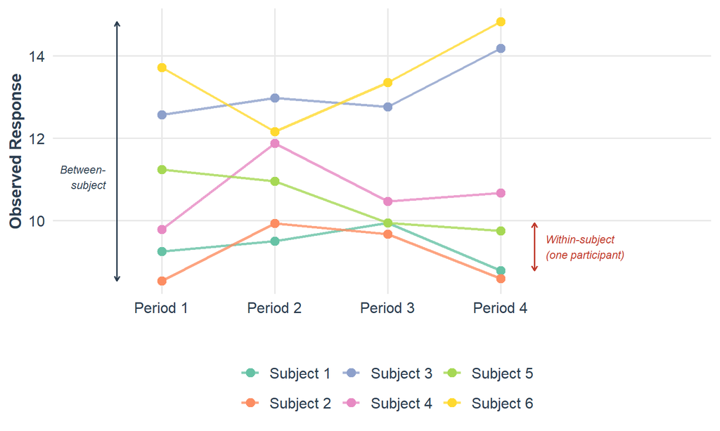

Figure 2: Between- and within-subject variability across four periods. Crossover analysis removes the between-subject component from the treatment comparison; the extra periods let you estimate the within-subject component directly.

- **Between-subject variance** ($\sigma_b^2$) — differences in baseline level across participants. Dominates parallel-group trials; removed by within-subject differencing. Handled as a random subject effect.
- **Within-subject variance** ($\sigma_w^2$) — variation in one participant’s response to the same treatment on different occasions. This is what drives your sample size. In replicated designs it can be estimated per treatment.
- **Period-to-period variation** — temporal trends, seasonality, practice effects. Handled as a fixed period effect; biases the comparison only if the design is unbalanced.

## 4.3 Biases to design against

Table 5: Systematic effects in multi-crossover trials, and how to handle them.

[output not shown]

## 4.4 Analysis methods

For a continuous outcome the **linear mixed-effects model** is the default: fixed effects for treatment, period and sequence, a random intercept for participant, and optionally a carryover term. It tolerates unbalanced data from dropout and yields both subject-specific and population-average estimates.

Table 6: Analytical options and when each applies.

| Method | Outcome Type | Estimand | Notes |
| --- | --- | --- | --- |
| Linear mixed model (LMM) | Continuous | Subject-specific and population-average | Default choice; handles missing data under MAR; assumes normal residuals |
| Generalized linear mixed model (GLMM) | Binary, count | Subject-specific (conditional) | Logit or log link; convergence can be fragile with small N |
| Generalized estimating equations (GEE) | Any (via link) | Population-average (marginal) | Needs adequate N for the sandwich estimator; no subject-specific estimates |
| Bayesian hierarchical model | Any | Subject-specific, full posterior | Best for small N, sparse data, and N-of-1 aggregation; prior sensitivity applies |
| Repeated measures ANOVA | Continuous | Population-average within blocks | Requires complete, balanced data and compound symmetry; largely superseded |

## 4.5 Handling carryover

**Prevent it by design.** An adequate washout, calibrated to pharmacokinetics *and* pharmacodynamics, is the primary safeguard. If the washout is pharmacologically defensible, the no-carryover assumption is defensible too.

**Assess it by analysis.** In a design with sufficient degrees of freedom — a four-period replicate or a Williams design — include first-order carryover as a fixed effect in a pre-specified sensitivity analysis. If the treatment estimate barely moves, you have empirical reassurance. If it moves a lot, re-examine the washout and qualify your conclusions.

**Do not use the old two-stage procedure.** Grizzle’s (1965) approach — test for carryover, then analyse as a crossover if non-significant and as a first-period parallel trial if significant — was dismantled by Senn (1993, 2002) on four grounds:

- The preliminary test has very low power, so a non-significant result is not evidence of absence.
- Conditioning the analysis on the test inflates the overall Type I error rate.
- It fails precisely when it is needed: undetected carryover leaves you with a biased crossover analysis.
- Reverting to first-period data discards the within-subject information that motivated the design.

**Critical reminder**

Never fall back on a first-period-only analysis because carryover was “detected”. Use a design in which carryover can be estimated directly, and report the sensitivity analysis alongside the primary one.

# 5 What you gain

## 5.1 Precision, and therefore sample size

Each additional period adds within-subject replication. For a two-treatment replicated design with *p* periods, the variance of the treatment effect is proportional to $1/p$, so relative to a two-period crossover it falls as $2/p$.

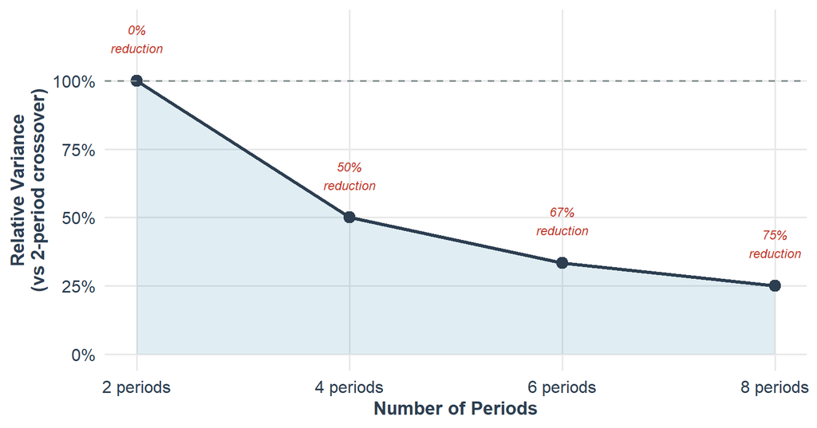

Figure 3: Variance of the treatment effect estimate relative to a two-period crossover, for two-treatment replicated designs with an even number of periods (2/p). Odd-period designs are not on this curve.

Against a **parallel-group** trial the gain is larger still, and it scales with the intraclass correlation. Using total participants and a common effect size $\delta$ on the total-SD scale, the ratio of crossover to parallel sample size is $(1-\text{ICC})\cdot 2/p$.

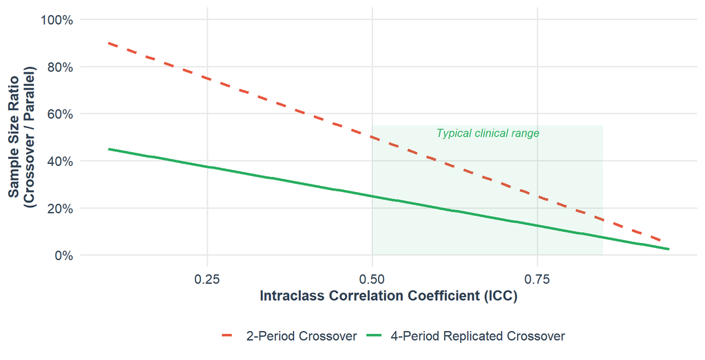

Figure 4: Total sample size for a crossover design as a proportion of the parallel-group requirement, as a function of the ICC. Ratio = (1 − ICC) × 2/p, matching the sample size formula in Section 3.

For ICC between 0.5 and 0.8 — common for pharmacokinetic endpoints, physiological measurements and symptom scores — a two-period crossover needs roughly **20–50%** of the parallel-group sample size, and a four-period replicate roughly **10–25%**.

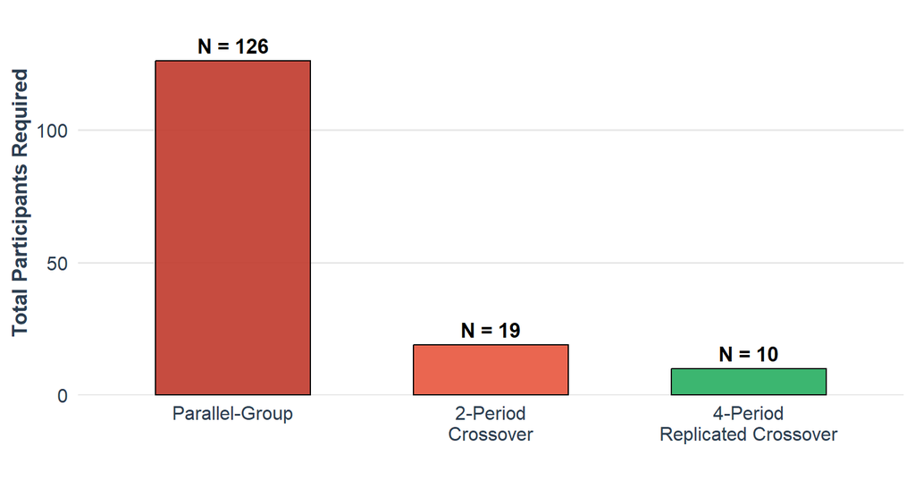

This is decisive in **rare diseases, paediatric subgroups and narrow phenotypes**, where a parallel trial simply cannot be powered. At the limit, N-of-1 designs use repeated crossover cycles within a single patient, and aggregating several N-of-1 trials recovers population-level estimates.

## 5.2 Confounding, and repeated self-control

Because every participant receives every treatment, there is no baseline imbalance to worry about: confounding by any **stable** participant-level characteristic — measured or not — is eliminated by construction. This does *not* extend to time-varying confounders, carryover, or differential dropout, all of which remain live threats.

Repetition adds two things beyond the group mean: **individual-level treatment effects**, and the **reproducibility** of those effects across occasions, which distinguishes consistent responders from noisy ones.

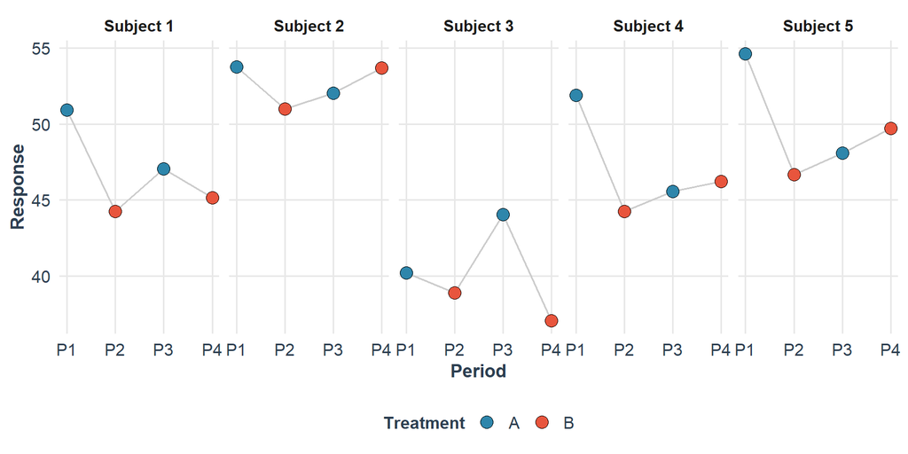

Figure 6: Within-subject comparisons in a four-period replicated crossover (ABAB). Each participant contributes multiple paired A-vs-B contrasts.

## 5.3 Where the design fits

Table 7: Suitability by treatment onset and offset characteristics.

| Treatment Characteristic | Examples | Suitability |
| --- | --- | --- |
| Rapid onset and offset (hours to days) | Bronchodilators, acute analgesics, PK studies | Excellent — short periods allow many cycles |
| Moderate onset and offset (days to weeks) | Antihypertensives, antihistamines, migraine prophylaxis | Good — feasible period and washout durations |
| Slow onset, prolonged effect (weeks to months) | Antidepressants, immunomodulators | Limited — long washouts stretch the trial badly |
| Permanent or disease-modifying effect | Vaccines, gene therapies, surgical interventions | Not suitable — reversibility assumption fails |

# 6 What it costs

## 6.1 Dropout and duration

Every extra period means more visits, more assessments and more elapsed time, so withdrawal accumulates.

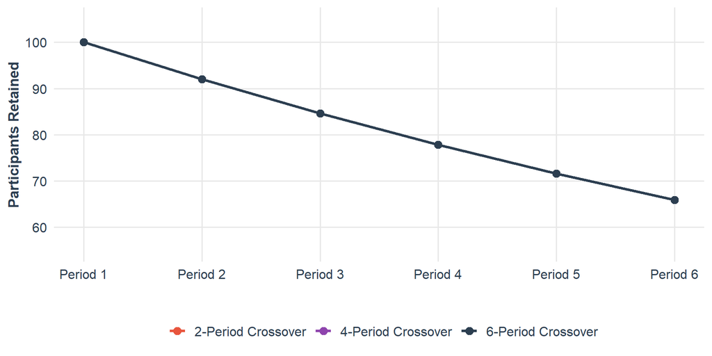

Figure 7: Retention under a constant 8% per-period dropout, for designs of 2, 4 and 6 periods. Multi-crossover designs lose more participants in absolute terms, but a partial completer still contributes within-subject information.

Worse, if dropout is **differential** — participants leaving preferentially during a poorly tolerated treatment — the missing-at-random assumption behind your primary analysis fails.

Total participant time is:

$$T_{\text{total}} = T_{\text{screen}} + T_{\text{run-in}} + p \cdot T_{\text{treatment}} + (p - 1) \cdot T_{\text{washout}}$$

Table 8: Total duration for representative configurations (screening 2 weeks, run-in 2 weeks).

| Design | Periods | Treatment (weeks) | Washout (weeks) | Total (weeks) | Total (months) |
| --- | --- | --- | --- | --- | --- |
| 2-period (standard crossover) | 2 | 4 | 2 | 14 | 3.2 |
| 3-period (Williams, 3 treatments) | 3 | 4 | 2 | 20 | 4.6 |
| 4-period (replicated crossover) | 4 | 4 | 2 | 26 | 6.0 |
| 4-period (short treatment periods) | 4 | 2 | 1 | 15 | 3.5 |
| 6-period (N-of-1, 3 pairs) | 6 | 2 | 1 | 21 | 4.8 |

Long per-participant timelines also carry an opportunity cost: delayed evidence, delayed regulatory decisions.

## 6.2 Assumptions that must actually hold

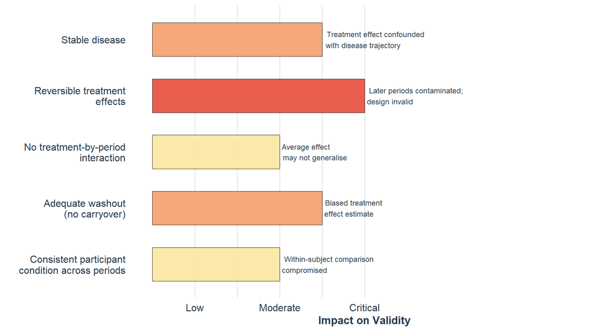

Figure 8: Core assumptions and the consequence of violating each.

Table 9: Settings where a crossover design should not be used.

| Clinical Setting | Assumption Violated | Reason |
| --- | --- | --- |
| Oncology (curative chemotherapy) | Reversibility; disease modification | Disease state is irreversibly altered |
| Vaccine trials | Reversibility (immune memory) | Immune response persists; no washout is possible |
| Surgical interventions | Reversibility (structural change) | Anatomical changes are permanent |
| Gene therapy | Reversibility (permanent modification) | Irreversible by design |
| Acute infections | Stable disease (self-limiting) | Condition resolves spontaneously |
| Rapidly progressive neurodegeneration | Stable disease (progressive) | Progression between periods confounds the comparison |

## 6.3 Carryover survives washout more often than you’d like

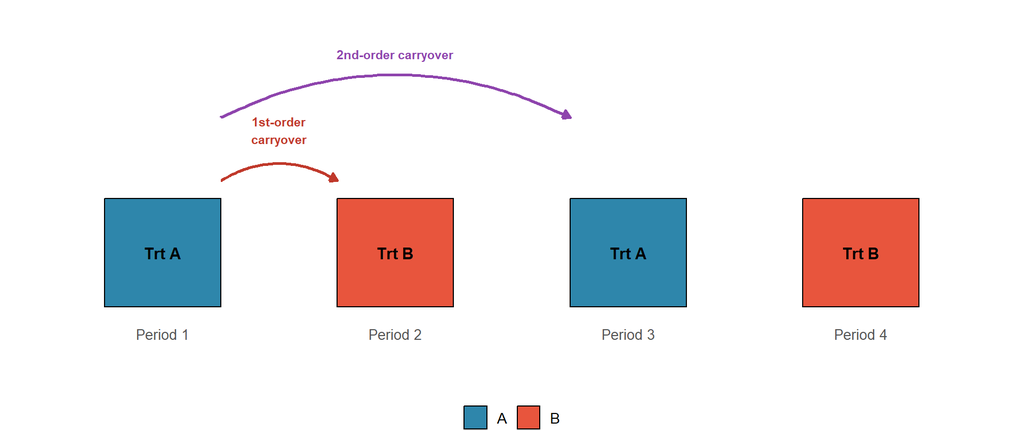

Figure 9: First- and higher-order carryover in a four-period design. Balanced designs protect against first-order carryover, not higher-order.

Three mechanisms defeat a nominally adequate washout:

- **Pharmacodynamic persistence** — enzyme induction or receptor downregulation outlasts drug clearance.
- **Psychological carryover** — the experience of one treatment colours how symptoms are perceived and reported on the next. No washout removes this.
- **Higher-order carryover** — residual effects from two or more periods back. Balanced designs distribute first-order carryover evenly; they offer no equivalent protection here.

## 6.4 Missing data gets complicated

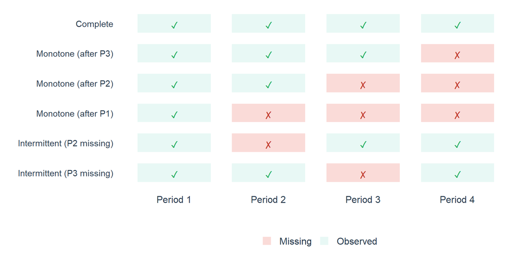

Figure 10: Missing data patterns in a four-period design: monotone dropout versus intermittent non-response.

Pre-specify a **primary analysis under MAR** using mixed models, plus **sensitivity analyses under MNAR** — pattern-mixture models, tipping-point analyses, or controlled imputation — and a rule for handling partial period data and intercurrent events under the ICH E9(R1) estimand framework.

## 6.5 Functional unblinding

Crossover participants can compare their own experiences across periods, which a parallel-group participant cannot. Distinct side-effect profiles, formulation differences, or a large efficacy gap can all reveal treatment identity, and the risk rises with each additional period.

Mitigations — active placebo, matched formulations, double-dummy administration, objective co-primary endpoints, and a post-study blinding index (James or Bang) — reduce the problem without eliminating it. Build them in at the design stage.

# 7 Case studies

Registry identifiers, sample sizes and design descriptions below should be re-verified against the primary sources before publication.

**Replicated designs**

Replicated crossovers dominate bioequivalence work, where the goal is to estimate intra-subject variability for reference-scaled assessment of highly variable drugs.

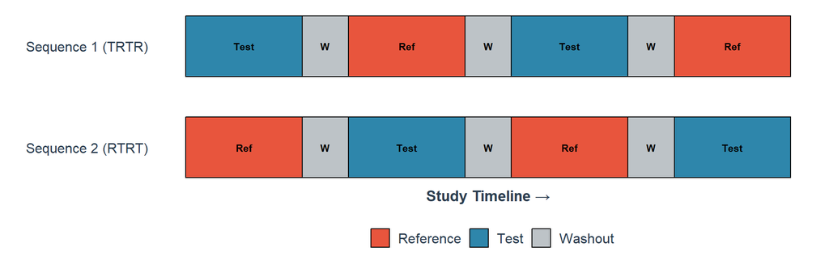

Figure 11: Full-replicate crossover (TRTR/RTRT): each formulation is given twice.

Table 10: Examples of replicated crossover designs.

| Trial | Registry | Design | Key Feature |
| --- | --- | --- | --- |
| Albendazole bioequivalence | NCT06201559 | 4-period, 2-sequence full replicate (TRTR / RTRT) | Test and reference 400 mg tablets each given twice per participant, enabling intra-subject variability estimation for both formulations |
| Desmopressin nasal spray bioequivalence | PMID 14564429 | 4-period, 2-sequence replicate | High PK variability of intranasal peptides would have made a 2-period design impractically large; each formulation given twice with ≥ 1-week washout |

**Partial replicate (3-period, 2-treatment)**

An intermediate between the standard crossover and the full replicate: the reference is given twice, the test once, so reference within-subject variability is estimable with one fewer period.

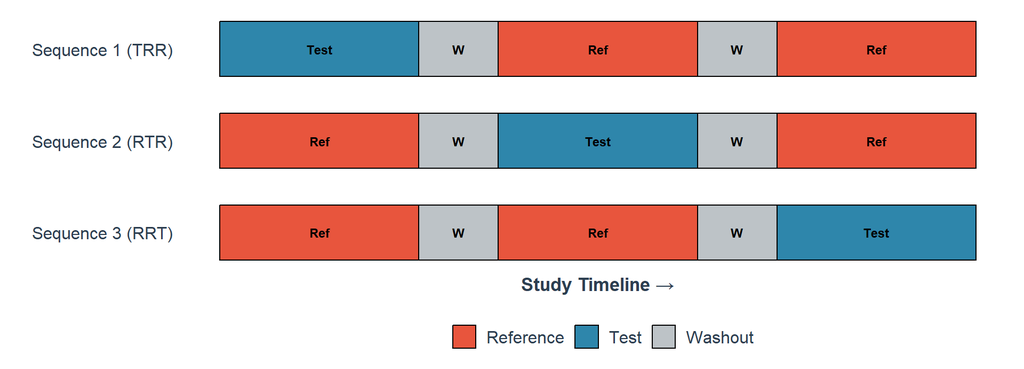

Figure 12: Partially replicated three-period design (TRR / RTR / RRT).

**Captopril bioequivalence (NCT04878315)** used exactly this FDA-recommended structure, giving the reference twice to support reference-scaled assessment while sparing participants a fourth period.

**Ibandronic acid bioequivalence** (*Drugs in R&D*, 2014) used the same three-way, reference-replicated family with a 14-day washout, single-dose, open-label, fasting.

**Williams designs**

Used when three or more treatments need simultaneous within-subject comparison with first-order carryover balance.

Table 11: Examples of Williams design trials.

| Trial | Reference | Design | Treatments | Key Feature |
| --- | --- | --- | --- | --- |
| Naloxone PK evaluation | NCT05363501 | 4-period, 4-sequence Williams design | Naloxone nasal swab, nasal spray, intramuscular injection | Registered explicitly as a balanced 4-way Williams crossover; each formulation preceded and followed every other equally often |
| Centanafadine thorough QT study | Published (Otsuka / Supernus) | 3-period, 6-sequence Williams square | Centanafadine, placebo, moxifloxacin (positive control) | Double-blind, full-block Williams square in 30 healthy adults, randomisation stratified by sex |

**Three treatments, three periods**

Table 12: Three-period, three-treatment crossover trials.

[output not shown]

**Balaam’s design**

Two periods, four sequences. The same-treatment arms (AA, BB) let you estimate the direct treatment effect *and* the carryover effect consistently — the alternative route to the problem multi-period designs solve.

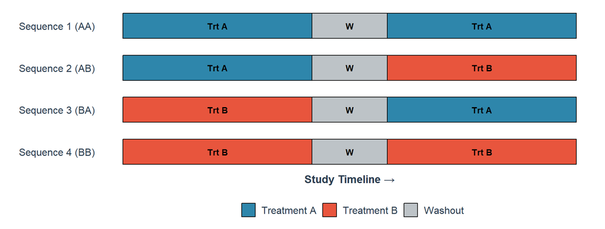

Figure 13: Balaam’s design (AA / AB / BA / BB).

A montelukast trial in perennial allergic rhinitis (*Allergy Asthma Proc*, 2008) used this structure to assess nasal congestion and sleep disturbance against placebo, with the same-treatment sequences supporting formal carryover estimation.

# 8 Summary

Multi-crossover designs extend the standard crossover into something considerably more informative: treatment-specific within-subject variances, carryover that can be estimated rather than assumed away, more than two treatments at once, and real tolerance of dropout.

That comes at a price — longer trials, harder logistics, more demanding assumptions, and a persistent risk of carryover and functional unblinding. Use them when the assumptions are genuinely defensible, not merely convenient.

Table 13: Multi-crossover designs at a glance.

| **Applicability** |  |
| --- | --- |
| Use when | The condition is chronic, stable and symptomatically managed |
|  | Treatment effects are reversible and short-acting |
|  | Between-subject variability is high relative to within-subject |
|  | The eligible population is small (rare disease, paediatric subgroups) |
| **Contraindications** |  |
| Avoid when | The treatment is curative or disease-modifying |
|  | The disease is progressive, episodic or self-limiting |
|  | Adequate washout cannot be assured |
| **Statistical** |  |
| Statistical | Pre-specify the estimand, then choose the model to match it |
|  | Design for washout; analyse under no-carryover, with a carryover-adjusted sensitivity analysis |
|  | Mixed models under MAR as primary; pre-specify MNAR sensitivity analyses; simulate before committing |
| **Operational** |  |
| Operational | Plan sequence-specific drug supply across multiple switches per participant |
|  | Train sites on period-specific baselines and washout compliance |
|  | Inflate the sample size for dropout across all periods |

# 9 References

## 9.1 Trials and examples

- [Albendazole bioequivalence study (NCT06201559)](https://clinicaltrials.gov/study/NCT06201559)
- [Desmopressin nasal spray replicate bioequivalence study (PMID 14564429)](https://europepmc.org/article/MED/14564429)
- [Naloxone pharmacokinetic evaluation (NCT05363501)](https://clinicaltrials.gov/study/NCT05363501)
- [Captopril bioequivalence study (NCT04878315)](https://ichgcp.net/clinical-trials-registry/NCT04878315)
- [Ibandronic acid bioequivalence — *Drugs in R&D*, 2014](https://pmc.ncbi.nlm.nih.gov/articles/PMC4070455/)
- [Centanafadine thorough QT study](https://pmc.ncbi.nlm.nih.gov/articles/PMC12314114/)
- [Montelukast in perennial allergic rhinitis — *Allergy Asthma Proc*, 2008](https://doi.org/10.2500/aap.2008.29.3097)
- [Contact lens corneal endothelial response (modified Balaam’s design)](https://pubmed.ncbi.nlm.nih.gov/18997540/)
- [PT007 asthma study (NCT06644924)](https://clinicaltrials.gov/study/NCT06644924)
- [BADGER — paediatric asthma step-up therapy (Lemanske et al., NEJM 2010)](https://www.nejm.org/doi/pdf/10.1056/NEJMoa1001278)
- [Peace & Koch, 1993 — three-period crossover where the high dose cannot be given first](https://europepmc.org/article/MED/8485531)

## 9.2 Methodological

- Williams, E. J. (1949). *Experimental designs balanced for the estimation of residual effects of treatments.* Aust J Sci Res A, 2, 149–168.
- Grizzle, J. E. (1965). *The two-period change-over design and its use in clinical trials.* Biometrics, 21, 467–480.
- Senn, S. J. (1993). *Cross-over Trials in Clinical Research* (1st ed.). Wiley.
- Senn, S. J. (2002). *Cross-over Trials in Clinical Research* (2nd ed.). Wiley.
- Senn, S. J. (2001). *Cross-over trials in drug development: theory and practice.* J Stat Plan Inference, 96, 29–40.
- Jones, B., & Kenward, M. G. (2015). *Design and Analysis of Cross-Over Trials* (3rd ed.). Chapman & Hall/CRC.
- Wellek, S., & Blettner, M. (2012). *On the proper use of the crossover design in clinical trials.* Dtsch Arztebl Int, 109(15), 276–281.
- Hemming, K., Taljaard, M., Weijer, C., & Forbes, A. B. (2020). *Use of multiple period, cluster randomised, crossover trial designs for comparative effectiveness research.* BMJ, 371:m3800.
- ICH E9(R1). *Addendum on estimands and sensitivity analysis in clinical trials.*
- FDA (2021). *Bioequivalence Studies With Pharmacokinetic Endpoints for Drugs Submitted Under an ANDA.*
- FDA (2022). *Statistical Approaches to Establishing Bioequivalence* (draft revision 1).
- [Latin squares and Williams designs — reference page](https://statpages.info/latinsq.html)